# DATA612Project2

## Visualization

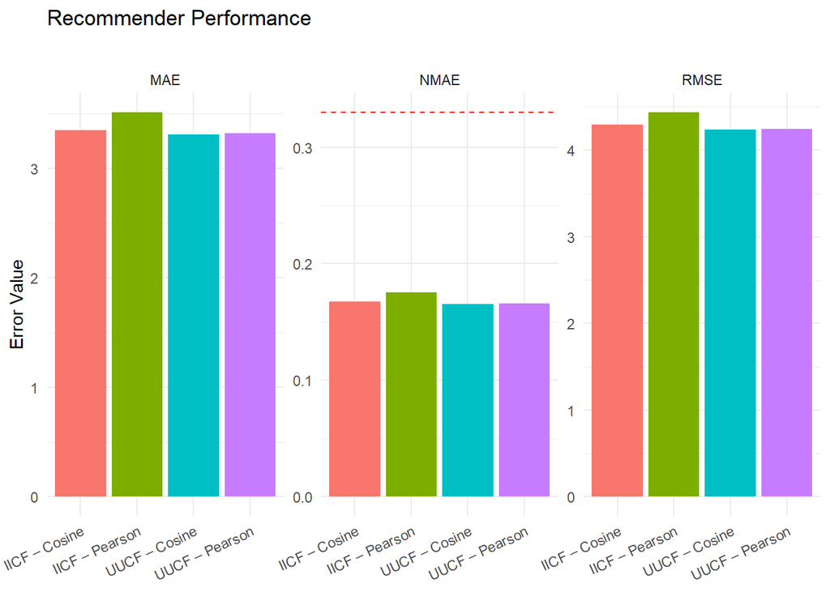

```r
results_long <- results %>%
  pivot_longer(cols = c(RMSE, MAE, NMAE), names_to = "Metric", values_to = "Value")

ggplot(results_long, aes(x = Algorithm, y = Value, fill = Algorithm)) +
  geom_col(show.legend = FALSE) +
  facet_wrap(~Metric, scales = "free_y") +
  geom_hline(data = data.frame(Metric = "NMAE", y = 0.33),
             aes(yintercept = y), linetype = "dashed", color = "red") +
  labs(
    title    = "Recommender Performance",
    subtitle = "",
    x        = NULL,
    y        = "Error Value"
  ) +
  theme_minimal() +
  theme(axis.text.x = element_text(angle = 25, hjust = 1))
```

## Summary and Findings

**How do we know it’s working?**

All four algorithms produce NMAE values between 0.165 and 0.176 which is well below the 0.33 baseline you’d get from random guessing on this dataset as shown in the original Jester paper. That’s roughly half the error of random guessing, which tells us the models are picking up real signal from the rating patterns.

**What performed best?**

UUCF with Cosine similarity came out on top with the lowest RMSE, MAE and NMAE though the differences between methods are small. From what i know i expected pearson to work better because it accounts for individual rating bias but here cosine worked better so im guessing the bias correction matters less when so many users have rated the same jokes

**Potential issues:**

As always with these we deal with cold start issues. Also the scale has been extremely limited by my computing power. Computing pairwise similarities for 25000 users seems like it would have fried everything with a pcb in my building Also the train test split is random. usually with a rating system the training set is the older reviews and the test set is newer predictions. There is a component of time which we are not accounting for.

**Possible improvements:**

Bigger sample size whenever possible Also possibly different values of k to see where accuracy is higher. I just used K = 15 as per ai recommendation as a general baseline.

## References

Goldberg, K., Roeder, T., Gupta, D., & Perkins, C. (2001). Eigentaste: A Constant Time Collaborative Filtering Algorithm. *Information Retrieval*, 4(2), 133–151. https://goldberg.berkeley.edu/jester-data/